# Backtesting Strategy 2

```python
import pandas as pd
import numpy as np
import os
import matplotlib.pyplot as plt
import seaborn as sns
from mplfinance.original_flavor import candlestick_ohlc
import matplotlib.dates as mdates
import matplotlib.ticker as mticker
import yfinance as yf
from datetime import datetime
```

```python
# Suppress all warnings
import warnings
warnings.simplefilter(action='ignore', category=Warning)
```

```python
# Set the working directory
os.chdir(r"D:\Benson\aUpWork\Douglas Backtester Algo\Backtester Algorithm\Data")
```

```python
# Function to view all rows and columns
def view_all():
    pd.set_option('display.max_rows', None)  # Show all rows
    pd.set_option('display.max_columns', None)  # Show all columns
    print("Display set to show all rows and columns.")

# Function to reset display options to default
def reset_display():
    pd.reset_option('display.max_rows')
    pd.reset_option('display.max_columns')
    print("Display options reset to default.")

# Example Usage
view_all()  # Set to view all rows and columns
reset_display()  # Reset to default display settings
```

```
Display set to show all rows and columns.
Display options reset to default.
```

```python
# Load the excel data file
file_path = r"YMAG ETF Price & Dividends.xlsx"
YMAG = pd.read_excel(file_path)

# Convert 'Date' column to datetime
YMAG["Date"] = pd.to_datetime(YMAG["Date"])

# Drop unnecessary columns
YMAG = YMAG.drop(columns=['Vol.', 'Change %'])

# Display the first few rows
YMAG
```

|  | Date | Price | Open | High | Low |
| --- | --- | --- | --- | --- | --- |
| 0 | 2025-02-13 | 0.05 | NaN | NaN | NaN |
| 1 | 2025-02-13 | 18.19 | 18.05 | 18.20 | 18.00 |
| 2 | 2025-02-12 | 18.04 | 17.91 | 18.08 | 17.85 |
| 3 | 2025-02-11 | 18.01 | 18.07 | 18.12 | 17.95 |
| 4 | 2025-02-10 | 18.07 | 18.13 | 18.21 | 18.07 |
| ... | ... | ... | ... | ... | ... |
| 284 | 2024-02-06 | 20.20 | 20.16 | 20.28 | 20.05 |
| 285 | 2024-02-05 | 20.19 | 20.34 | 20.34 | 19.95 |
| 286 | 2024-02-02 | 20.30 | 20.18 | 20.32 | 19.99 |
| 287 | 2024-02-01 | 19.75 | 19.68 | 19.76 | 19.60 |
| 288 | 2024-01-31 | 19.49 | 19.69 | 19.69 | 19.45 |

289 rows × 5 columns

```python
# check for missing values in YMAX
YMAG.isnull().sum()
```

```
Date      0
Price     0
Open     28
High     28
Low      28
dtype: int64
```

```python
# Load the Excel data file
file_path = r"YMAX ETF Price & Dividends.xlsx"
YMAX = pd.read_excel(file_path)

# Convert 'Date' column to datetime
YMAX["Date"] = pd.to_datetime(YMAX["Date"])

# Drop unnecessary columns
YMAX = YMAX.drop(columns=['Vol.', 'Change %'])

# Display the first few rows
YMAX
```

|  | Date | Price | Open | High | Low |
| --- | --- | --- | --- | --- | --- |
| 0 | 2025-02-13 | 0.15 | NaN | NaN | NaN |
| 1 | 2025-02-13 | 16.64 | 16.47 | 16.64 | 16.38 |
| 2 | 2025-02-12 | 16.60 | 16.39 | 16.62 | 16.33 |
| 3 | 2025-02-11 | 16.41 | 16.57 | 16.63 | 16.39 |
| 4 | 2025-02-10 | 16.67 | 16.53 | 16.68 | 16.53 |
| ... | ... | ... | ... | ... | ... |
| 294 | 2024-01-24 | 20.36 | 20.51 | 20.53 | 20.35 |
| 295 | 2024-01-23 | 20.27 | 20.21 | 20.28 | 20.17 |
| 296 | 2024-01-22 | 20.18 | 20.13 | 20.31 | 20.11 |
| 297 | 2024-01-19 | 20.12 | 20.03 | 20.12 | 19.88 |
| 298 | 2024-01-18 | 19.92 | 21.00 | 21.35 | 19.82 |

299 rows × 5 columns

```python
# Check for missing values in YMAX
YMAX.isnull().sum()
```

```
Date      0
Price     0
Open     29
High     29
Low      29
dtype: int64
```

```python
#Extracting the Dividends data
# Create a new DataFrame with only rows where 'Open' is NaN
YMAX_Dividends = YMAX[YMAX['Open'].isna()].copy()

# Drop unnecessary columns
YMAX_Dividends = YMAX_Dividends.drop(columns=['Open', 'High', 'Low'])

# Rename 'Price' column to 'Dividends'
YMAX_Dividends = YMAX_Dividends.rename(columns={'Price': 'YMAX Dividends'})

# Display the new DataFrame
YMAX_Dividends
```

|  | Date | YMAX Dividends |
| --- | --- | --- |
| 0 | 2025-02-13 | 0.15 |
| 6 | 2025-02-06 | 0.19 |
| 12 | 2025-01-30 | 0.15 |
| 18 | 2025-01-23 | 0.17 |
| 23 | 2025-01-16 | 0.11 |
| 29 | 2025-01-08 | 0.14 |
| 33 | 2025-01-03 | 0.18 |
| 38 | 2024-12-27 | 0.25 |
| 44 | 2024-12-19 | 0.14 |
| 50 | 2024-12-12 | 0.12 |
| 56 | 2024-12-05 | 0.24 |
| 61 | 2024-11-29 | 0.31 |
| 67 | 2024-11-21 | 0.24 |
| 73 | 2024-11-14 | 0.15 |
| 79 | 2024-11-07 | 0.12 |
| 85 | 2024-10-31 | 0.23 |
| 91 | 2024-10-24 | 0.23 |
| 97 | 2024-10-17 | 0.18 |
| 103 | 2024-10-10 | 0.20 |
| 109 | 2024-10-03 | 0.21 |
| 115 | 2024-09-26 | 0.22 |
| 121 | 2024-09-19 | 0.23 |
| 146 | 2024-08-15 | 0.59 |
| 168 | 2024-07-17 | 0.65 |
| 190 | 2024-06-14 | 0.73 |
| 212 | 2024-05-15 | 0.73 |
| 233 | 2024-04-17 | 0.63 |
| 257 | 2024-03-14 | 0.57 |
| 277 | 2024-02-15 | 0.53 |

```python
#Extracting the Dividends data
# Create a new DataFrame with only rows where 'Open' is NaN
YMAG_Dividends = YMAG[YMAG['Open'].isna()].copy()

# Drop unnecessary columns
YMAG_Dividends = YMAG_Dividends.drop(columns=['Open', 'High', 'Low'])

# Rename 'Price' column to 'Dividends'
YMAG_Dividends = YMAG_Dividends.rename(columns={'Price': 'YMAG Dividends'})

# Display the new DataFrame
YMAG_Dividends
```

|  | Date | YMAG Dividends |
| --- | --- | --- |
| 0 | 2025-02-13 | 0.05 |
| 6 | 2025-02-06 | 0.19 |
| 12 | 2025-01-30 | 0.19 |
| 18 | 2025-01-23 | 0.10 |
| 23 | 2025-01-16 | 0.05 |
| 29 | 2025-01-08 | 0.16 |
| 33 | 2025-01-03 | 0.31 |
| 38 | 2024-12-27 | 0.17 |
| 44 | 2024-12-19 | 0.06 |
| 55 | 2024-12-05 | 0.28 |
| 60 | 2024-11-29 | 0.20 |
| 66 | 2024-11-21 | 0.06 |
| 72 | 2024-11-14 | 0.21 |
| 78 | 2024-11-07 | 0.21 |
| 84 | 2024-10-31 | 0.15 |
| 90 | 2024-10-24 | 0.06 |
| 96 | 2024-10-17 | 0.23 |
| 102 | 2024-10-10 | 0.28 |
| 108 | 2024-10-03 | 0.16 |
| 114 | 2024-09-26 | 0.17 |
| 120 | 2024-09-19 | 0.20 |
| 145 | 2024-08-15 | 0.58 |
| 167 | 2024-07-17 | 0.64 |
| 189 | 2024-06-14 | 0.68 |
| 211 | 2024-05-15 | 0.64 |
| 232 | 2024-04-17 | 0.62 |
| 256 | 2024-03-14 | 0.59 |
| 276 | 2024-02-15 | 0.43 |

```python
#check for missing values in YMAG_Dividends
print(YMAG_Dividends.isnull().sum())
print(YMAX_Dividends.isnull().sum())
```

```
Date              0
YMAG Dividends    0
dtype: int64
Date              0
YMAX Dividends    0
dtype: int64
```

```python
# Drop all rows with NaN values in YMAX and YMAG, to remove the duplicate rows where dividends were
YMAX = YMAX.dropna()
YMAG = YMAG.dropna()
```

```python
# Merge dividends with YMAX price data
YMAX = YMAX.merge(YMAX_Dividends, on="Date", how="left")
YMAX["YMAX Dividends"].fillna(0, inplace=True)  # Fill missing dividends with 0

# Merge dividends with YMAG price data
YMAG = YMAG.merge(YMAG_Dividends, on="Date", how="left")
YMAG["YMAG Dividends"].fillna(0, inplace=True)  # Fill missing dividends with 0

# Rename price in YMAX to YMAX
YMAX = YMAX.rename(columns={'Price': 'YMAX'})

# Rename price in YMAG to YMAG
YMAG = YMAG.rename(columns={'Price': 'YMAG'})

# Display merged data
YMAX.head()
```

|  | Date | YMAX | Open | High | Low | YMAX Dividends |
| --- | --- | --- | --- | --- | --- | --- |
| 0 | 2025-02-13 | 16.64 | 16.47 | 16.64 | 16.38 | 0.15 |
| 1 | 2025-02-12 | 16.60 | 16.39 | 16.62 | 16.33 | 0.00 |
| 2 | 2025-02-11 | 16.41 | 16.57 | 16.63 | 16.39 | 0.00 |
| 3 | 2025-02-10 | 16.67 | 16.53 | 16.68 | 16.53 | 0.00 |
| 4 | 2025-02-07 | 16.44 | 16.51 | 16.69 | 16.40 | 0.00 |

```python
# Display merged data
YMAG.head()
```

|  | Date | YMAG | Open | High | Low | YMAG Dividends |
| --- | --- | --- | --- | --- | --- | --- |
| 0 | 2025-02-13 | 18.19 | 18.05 | 18.20 | 18.00 | 0.05 |
| 1 | 2025-02-12 | 18.04 | 17.91 | 18.08 | 17.85 | 0.00 |
| 2 | 2025-02-11 | 18.01 | 18.07 | 18.12 | 17.95 | 0.00 |
| 3 | 2025-02-10 | 18.07 | 18.13 | 18.21 | 18.07 | 0.00 |
| 4 | 2025-02-07 | 18.07 | 18.24 | 18.34 | 18.00 | 0.00 |

```python
# check and print sum of missing values in YMAX
print(YMAX.isnull().sum())

# check and print sum of missing values in YMAG
print(YMAG.isnull().sum())
```

```
Date              0
YMAX              0
Open              0
High              0
Low               0
YMAX Dividends    0
dtype: int64
Date              0
YMAG              0
Open              0
High              0
Low               0
YMAG Dividends    0
dtype: int64
```

```python
# Merge dividends with YMAX price data
YMAG_YMAX_Divs_n_prices = YMAX[["Date", "YMAX", "YMAX Dividends"]].merge(YMAG[["Date", "YMAG", "YMAG Dividends"]],
                                                                         on="Date", how="left")

#check and print the sum of missing values
print(YMAG_YMAX_Divs_n_prices.isna().sum())

# Drop all rows with NaN values in YMAG_YMAX_Divs_n_prices
YMAG_YMAX_Divs_n_prices = YMAG_YMAX_Divs_n_prices.dropna()
print("sum of missing values after dropping them")
print(YMAG_YMAX_Divs_n_prices.isna().sum())
```

```
Date              0
YMAX              0
YMAX Dividends    0
YMAG              9
YMAG Dividends    9
dtype: int64
sum of missing values after dropping them
Date              0
YMAX              0
YMAX Dividends    0
YMAG              0
YMAG Dividends    0
dtype: int64
```

```python
# Convert 'Date' column to datetime format
YMAG_YMAX_Divs_n_prices['Date'] = pd.to_datetime(YMAG_YMAX_Divs_n_prices['Date'])

# Set 'Date' as the index
YMAG_YMAX_Divs_n_prices.set_index('Date', inplace=True)

YMAG_YMAX_Divs_n_prices
```

| Date | YMAX | YMAX Dividends | YMAG | YMAG Dividends |
| --- | --- | --- | --- | --- |
| 2025-02-13 | 16.64 | 0.15 | 18.19 | 0.05 |
| 2025-02-12 | 16.60 | 0.00 | 18.04 | 0.00 |
| 2025-02-11 | 16.41 | 0.00 | 18.01 | 0.00 |
| 2025-02-10 | 16.67 | 0.00 | 18.07 | 0.00 |
| 2025-02-07 | 16.44 | 0.00 | 18.07 | 0.00 |
| ... | ... | ... | ... | ... |
| 2024-02-06 | 20.61 | 0.00 | 20.20 | 0.00 |
| 2024-02-05 | 20.44 | 0.00 | 20.19 | 0.00 |
| 2024-02-02 | 20.70 | 0.00 | 20.30 | 0.00 |
| 2024-02-01 | 20.39 | 0.00 | 19.75 | 0.00 |
| 2024-01-31 | 20.20 | 0.00 | 19.49 | 0.00 |

261 rows × 4 columns

```python
# Download the data of VIX, VVIX, and QQQ ETF
VIX = yf.download('^VIX', start='2024-01-01', end='2025-02-14')
VVIX = yf.download('^VVIX', start='2024-01-01', end='2025-02-14')
QQQ = yf.download('QQQ', start='2024-01-01', end='2025-02-14')

# Rename the columns
VIX.columns = ['Close', 'High', 'Low', 'Open', 'Volume']
VVIX.columns = ['Close', 'High', 'Low', 'Open', 'Volume']
QQQ.columns = ['Close', 'High', 'Low', 'Open', 'Volume']

# Rename "Close" column and drop other columns
VIX = VIX[['Close']].rename(columns={'Close': 'VIX'})
VVIX = VVIX[['Close']].rename(columns={'Close': 'VVIX'})
QQQ = QQQ[['Close']].rename(columns={'Close': 'QQQ'})
```

```
[*********************100%***********************]  1 of 1 completed
[*********************100%***********************]  1 of 1 completed
[*********************100%***********************]  1 of 1 completed
```

```python
# Merge VIX, VVIX, and QQQ DataFrames on the Date index
merged_vix_vvix_qqq_df = VIX \
    .merge(VVIX, left_index=True, right_index=True, how='outer') \
    .merge(QQQ, left_index=True, right_index=True, how='outer')

# Merge the VIX, VVIX, and QQQ DataFrames with the YMAG_YMAX_Divs_n_prices DataFrame
All_Assets = YMAG_YMAX_Divs_n_prices.merge(merged_vix_vvix_qqq_df, left_index=True, right_index=True, how='outer')

#Drop the NaN values
All_Assets = All_Assets.dropna()

# Sort the DataFrame by 'Date' in descending order
All_Assets = All_Assets.sort_values(by='Date', ascending=True)

# Print the sum of missing values in each column
print("The sum of missing values in each column:")
print(All_Assets.isnull().sum())
```

```
The sum of missing values in each column:
YMAX              0
YMAX Dividends    0
YMAG              0
YMAG Dividends    0
VIX               0
VVIX              0
QQQ               0
dtype: int64
```

```python
# print rhe info of the merged DataFrame
All_Assets.info()
```

```
<class 'pandas.core.frame.DataFrame'>
DatetimeIndex: 261 entries, 2024-01-31 to 2025-02-13
Data columns (total 7 columns):
 #   Column          Non-Null Count  Dtype
---  ------          --------------  -----
 0   YMAX            261 non-null    float64
 1   YMAX Dividends  261 non-null    float64
 2   YMAG            261 non-null    float64
 3   YMAG Dividends  261 non-null    float64
 4   VIX             261 non-null    float64
 5   VVIX            261 non-null    float64
 6   QQQ             261 non-null    float64
dtypes: float64(7)
memory usage: 16.3 KB
```

```python
# Display the first few rows of the merged DataFrame
All_Assets
```

| Date | YMAX | YMAX Dividends | YMAG | YMAG Dividends | VIX | VVIX | QQQ |
| --- | --- | --- | --- | --- | --- | --- | --- |
| 2024-01-31 | 20.20 | 0.00 | 19.49 | 0.00 | 14.350000 | 87.559998 | 414.506714 |
| 2024-02-01 | 20.39 | 0.00 | 19.75 | 0.00 | 13.880000 | 84.830002 | 419.387726 |
| 2024-02-02 | 20.70 | 0.00 | 20.30 | 0.00 | 13.850000 | 83.309998 | 426.475616 |
| 2024-02-05 | 20.44 | 0.00 | 20.19 | 0.00 | 13.670000 | 79.580002 | 425.918915 |
| 2024-02-06 | 20.61 | 0.00 | 20.20 | 0.00 | 13.060000 | 76.970001 | 425.063995 |
| ... | ... | ... | ... | ... | ... | ... | ... |
| 2025-02-07 | 16.44 | 0.00 | 18.07 | 0.00 | 16.540001 | 101.489998 | 522.919983 |
| 2025-02-10 | 16.67 | 0.00 | 18.07 | 0.00 | 15.810000 | 99.150002 | 529.250000 |
| 2025-02-11 | 16.41 | 0.00 | 18.01 | 0.00 | 16.020000 | 99.820000 | 527.989990 |
| 2025-02-12 | 16.60 | 0.00 | 18.04 | 0.00 | 15.890000 | 98.739998 | 528.299988 |
| 2025-02-13 | 16.64 | 0.15 | 18.19 | 0.05 | 15.100000 | 95.480003 | 535.900024 |

261 rows × 7 columns

```python
# Define rolling window size (e.g., 21 days)
window_size = 21

# Compute daily returns for each asset in All_Assets, excluding dividends columns
returns = All_Assets.loc[:, ~All_Assets.columns.str.contains('Dividends')].pct_change().dropna()

# Initialize stats_df with rolling volatilities
Prices_and_stats_df = pd.DataFrame(index=returns.index)

# Compute rolling correlations
Prices_and_stats_df["YMAX-VIX Correlation"] = returns["YMAX"].rolling(window=window_size).corr(returns["VIX"])
Prices_and_stats_df["YMAX-VVIX Correlation"] = returns["YMAX"].rolling(window=window_size).corr(returns["VVIX"])
Prices_and_stats_df["YMAG-VIX Correlation"] = returns["YMAG"].rolling(window=window_size).corr(returns["VIX"])
Prices_and_stats_df["YMAG-VVIX Correlation"] = returns["YMAG"].rolling(window=window_size).corr(returns["VVIX"])

#Merge the prices and stats data
Prices_and_stats_df = All_Assets.merge(Prices_and_stats_df, left_index=True, right_index=True)

# Drop NaN values resulting from rolling calculations
Prices_and_stats_df = Prices_and_stats_df.dropna()

# Rest the prices and stats data index
Prices_and_stats_df.reset_index(inplace=True)

# Display the first and last few rows of Prices_and_stats_df
Prices_and_stats_df
```

|  | Date | YMAX | YMAX Dividends | YMAG | YMAG Dividends | VIX | VVIX | QQQ | YMAX-VIX Correlation | YMAX-VVIX Correlation | YMAG-VIX Correlation | YMAG-VVIX Correlation |
| --- | --- | --- | --- | --- | --- | --- | --- | --- | --- | --- | --- | --- |
| 0 | 2024-03-01 | 21.67 | 0.00 | 21.00 | 0.00 | 13.110000 | 77.680000 | 442.977539 | -0.626499 | -0.549622 | -0.508677 | -0.456559 |
| 1 | 2024-03-04 | 21.60 | 0.00 | 20.74 | 0.00 | 13.490000 | 79.410004 | 441.396912 | -0.626533 | -0.549422 | -0.510632 | -0.458702 |
| 2 | 2024-03-05 | 21.17 | 0.00 | 20.41 | 0.00 | 14.460000 | 83.910004 | 433.473999 | -0.675417 | -0.589907 | -0.593275 | -0.510036 |
| 3 | 2024-03-06 | 21.38 | 0.00 | 20.37 | 0.00 | 14.500000 | 83.110001 | 436.197845 | -0.706867 | -0.681932 | -0.603820 | -0.546858 |
| 4 | 2024-03-07 | 21.65 | 0.00 | 20.65 | 0.00 | 14.440000 | 82.129997 | 442.818512 | -0.700723 | -0.679942 | -0.611949 | -0.559811 |
| ... | ... | ... | ... | ... | ... | ... | ... | ... | ... | ... | ... | ... |
| 235 | 2025-02-07 | 16.44 | 0.00 | 18.07 | 0.00 | 16.540001 | 101.489998 | 522.919983 | -0.720658 | -0.588653 | -0.744953 | -0.612972 |
| 236 | 2025-02-10 | 16.67 | 0.00 | 18.07 | 0.00 | 15.810000 | 99.150002 | 529.250000 | -0.776437 | -0.666927 | -0.760448 | -0.645467 |
| 237 | 2025-02-11 | 16.41 | 0.00 | 18.01 | 0.00 | 16.020000 | 99.820000 | 527.989990 | -0.749829 | -0.646186 | -0.772829 | -0.689207 |
| 238 | 2025-02-12 | 16.60 | 0.00 | 18.04 | 0.00 | 15.890000 | 98.739998 | 528.299988 | -0.779082 | -0.724501 | -0.777147 | -0.713569 |
| 239 | 2025-02-13 | 16.64 | 0.15 | 18.19 | 0.05 | 15.100000 | 95.480003 | 535.900024 | -0.775152 | -0.720788 | -0.796683 | -0.745236 |

240 rows × 12 columns

```python
# Export the data to excel
# Create a Pandas Excel writer using XlsxWriter as the engine
with pd.ExcelWriter('Strategy 2 Prices and Statistics.xlsx', engine='xlsxwriter') as writer:
    # Write Prices_and_stats_df to the first sheet
    Prices_and_stats_df.to_excel(writer, sheet_name='Prices and Correlations', index=False)

print(f"✅ Performance DataFrames successfully saved to 'Prices_and_stats_df.xlsx'")
```

```
✅ Performance DataFrames successfully saved to 'Prices_and_stats_df.xlsx'
```

## BACKTESTING THE INVESTMENT RULES

### **📌 Investment Rules for Strategy 2**

1. **Invest Only If:**
   - **VIX is between 15 and 20** (inclusive), **AND**
   - **VVIX is between 90 and 100** (i.e., VVIX is below 100 but not less than 90).

   > **Interpretation**: Go long on YMAX/YMAG (without a hedge) **only** when both conditions are met.
2. **Exit the Market If:**
   - **VIX drops below 15** or **rises above 20**, **OR**
   - **VVIX goes above or equal to 100, or falls below 90**.

   > **Interpretation**: If either VIX or VVIX is outside the desired range, close all positions and remain in cash.
3. **Re-Enter the Market When:**
   - **VIX is again within 15–20**, **AND**
   - **VVIX has stabilized in a tighter range – specifically, between 90 and 95 (inclusive).**

   > **Interpretation**: Re-enter only when both VIX is back in the 15–20 range and VVIX has come back to a “safe zone” (90–95).

### **🚀 Summary of Logic**

1. **In-Market Condition**:  
   $15 \leq \text{VIX} \leq 20$ **AND** $90 \leq \text{VVIX} < 100$.
2. **Exit Condition**:  
   $\text{VIX} < 15$ **OR** $\text{VIX} > 20$ **OR** $\text{VVIX} < 90$ **OR** $\text{VVIX} \geq 100$.
3. **Re-Entry Condition**:  
   $\text{VIX}$ returns to $[15,20]$ **AND** $\text{VVIX}$ is in the range $[90,95]$.

#### YMAX BACKTEST:

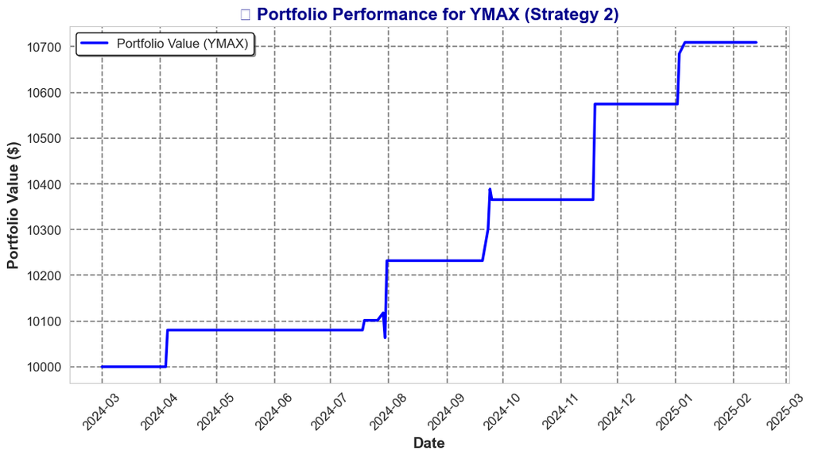

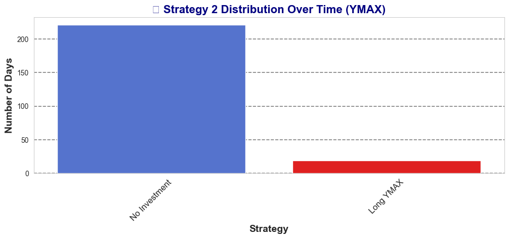

```python
# ------------------------------------------------------------
# 1) PREPARE THE DATA
# ------------------------------------------------------------
# DataFrame "Prices_and_stats_df" with Columns: ["Date", "YMAX", "YMAX Dividends", "VIX", "VVIX", ...]
# We copy it for this strategy's backtest on YMAX.
ymax_df = Prices_and_stats_df.copy()

# Define initial portfolio value
initial_investment = 10000.0  # $10,000 starting capital

# Sort by date to ensure chronological order
ymax_df.sort_values("Date", inplace=True)
ymax_df.reset_index(drop=True, inplace=True)

# ------------------------------------------------------------
# 2) DEFINE HELPER FUNCTIONS FOR CONDITIONS
# ------------------------------------------------------------
# function to check if it is time to enter the market or not
def in_market_condition(vix, vvix):
    """
    Condition for staying in the market once we're already invested:
    15 <= VIX <= 20, 90 <= VVIX < 100
    """
    return (15 <= vix <= 20) and (90 <= vvix < 100)

#function to check if it is time to re-enter the market or not
def reentry_condition(vix, vvix):
    """
    Stricter condition for re-entering the market after an exit:
    15 <= VIX <= 20, 90 <= VVIX <= 95
    """
    return (15 <= vix <= 20) and (90 <= vvix <= 95)

# function to check the exit condition if it is time to exit the market or not to exit
def exit_condition(vix, vvix):
    """
    If VIX < 15 or VIX > 20, or VVIX < 90 or VVIX >= 100 -> EXIT
    """
    return (vix < 15) or (vix > 20) or (vvix < 90) or (vvix >= 100)

# ------------------------------------------------------------
# 3) SET UP BACKTEST COLUMNS AND INITIAL VALUES
# ------------------------------------------------------------
ymax_df["Portfolio_Value"] = np.nan
ymax_df.loc[0, "Portfolio_Value"] = initial_investment

# Boolean: are we currently invested?
ymax_df["In_Market"] = False
ymax_df.loc[0, "In_Market"] = False

# Track how many shares of YMAX we hold
ymax_df["Shares_Held"] = 0.0
ymax_df.loc[0, "Shares_Held"] = 0.0

# Strategy label for each day
ymax_df["Strategy"] = "No Investment"

# ------------------------------------------------------------
# 4) BACKTEST LOOP
# ------------------------------------------------------------
for i in range(1, len(ymax_df)):
    # Copy forward previous day's portfolio value, in_market status, and shares
    ymax_df.loc[i, "Portfolio_Value"] = ymax_df.loc[i-1, "Portfolio_Value"]
    ymax_df.loc[i, "In_Market"] = ymax_df.loc[i-1, "In_Market"]
    ymax_df.loc[i, "Shares_Held"] = ymax_df.loc[i-1, "Shares_Held"]

    # Current day data
    vix_today = ymax_df.loc[i, "VIX"]
    vvix_today = ymax_df.loc[i, "VVIX"]
    ymax_price_today = ymax_df.loc[i, "YMAX"]
    ymax_div_today = ymax_df.loc[i, "YMAX Dividends"]

    # Are we in the market at the start of today?
    currently_in_market = ymax_df.loc[i-1, "In_Market"]

    if currently_in_market:
        # Check if we remain in the market or exit
        if exit_condition(vix_today, vvix_today):
            # EXIT: close position -> shares = 0, remain in cash
            ymax_df.loc[i, "In_Market"] = False
            ymax_df.loc[i, "Shares_Held"] = 0.0
            ymax_df.loc[i, "Strategy"] = "No Investment"
            # Portfolio_Value stays the same as yesterday's (carried forward)
        else:
            # REMAIN IN MARKET: update portfolio value based on today's price + dividend
            shares_held = ymax_df.loc[i, "Shares_Held"]
            new_portfolio_value = shares_held * (ymax_price_today + ymax_div_today)
            ymax_df.loc[i, "Portfolio_Value"] = new_portfolio_value
            ymax_df.loc[i, "Strategy"] = "Long YMAX"
    else:
        # currently out of market, check re-entry condition
        if reentry_condition(vix_today, vvix_today):
            # ENTER: buy shares with all capital
            cash_available = ymax_df.loc[i, "Portfolio_Value"]
            if ymax_price_today > 0:
                shares_bought = cash_available / ymax_price_today
                ymax_df.loc[i, "Shares_Held"] = shares_bought
                ymax_df.loc[i, "In_Market"] = True
                ymax_df.loc[i, "Strategy"] = "Long YMAX"
                # Immediately compute today's new portfolio value
                new_portfolio_value = shares_bought * (ymax_price_today + ymax_div_today)
                ymax_df.loc[i, "Portfolio_Value"] = new_portfolio_value
            else:
                # If price is 0 or invalid, skip
                ymax_df.loc[i, "Strategy"] = "No Investment"
        else:
            # Stay in cash
            ymax_df.loc[i, "Strategy"] = "No Investment"

# ------------------------------------------------------------
# 5) COMPUTE DAILY RETURNS
# ------------------------------------------------------------
ymax_df["Portfolio_Return"] = ymax_df["Portfolio_Value"].pct_change()

# ------------------------------------------------------------
# 6) VISUALIZE RESULTS
# ------------------------------------------------------------
sns.set_style("whitegrid")

# (A) Portfolio Performance Plot
plt.figure(figsize=(12, 6))
ax = sns.lineplot(
    x=ymax_df["Date"],
    y=ymax_df["Portfolio_Value"],
    color="blue",
    linewidth=2.5,
    label="Portfolio Value (YMAX)"
)

ax.xaxis.set_major_locator(mdates.MonthLocator())
ax.xaxis.set_major_formatter(mdates.DateFormatter("%Y-%m"))

plt.xlabel("Date", fontsize=14, fontweight="bold")
plt.ylabel("Portfolio Value ($)", fontsize=14, fontweight="bold")
plt.title("📈 Portfolio Performance for YMAX (Strategy 2)", fontsize=16, fontweight="bold", color="darkblue")
plt.xticks(rotation=45, fontsize=12)
plt.yticks(fontsize=12)
plt.grid(True, linestyle="--", linewidth=1.2, color="gray")
plt.legend(fontsize=12, loc="upper left", frameon=True, shadow=True, edgecolor="black")
plt.show()

# (B) Strategy Usage Over Time
plt.figure(figsize=(12, 4))
ax = sns.barplot(
    x=ymax_df["Strategy"].value_counts().index,
    y=ymax_df["Strategy"].value_counts().values,
    palette=["royalblue", "red", "green"]
)
plt.xlabel("Strategy", fontsize=14, fontweight="bold")
plt.ylabel("Number of Days", fontsize=14, fontweight="bold")
plt.title("📊 Strategy 2 Distribution Over Time (YMAX)", fontsize=16, fontweight="bold", color="navy")
plt.xticks(rotation=45, fontsize=12)
plt.grid(axis="y", linestyle="--", linewidth=1.2, color="gray")
plt.show()
```

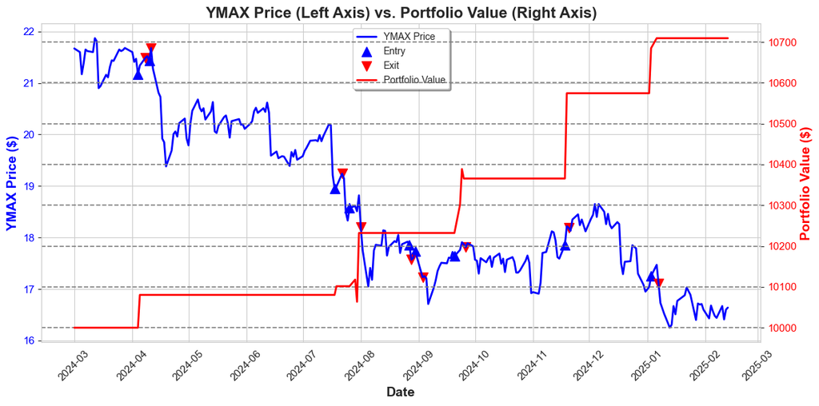

```python
# ---------------------------------------------
# STEP A: Identify Entry and Exit Days
# ---------------------------------------------
# Entry Day = Yesterday was out of market, today is in market
ymax_df["Entry"] = (ymax_df["In_Market"].shift(1) == False) & (ymax_df["In_Market"] == True)

# Exit Day = Yesterday was in market, today is out of market
ymax_df["Exit"] = (ymax_df["In_Market"].shift(1) == True) & (ymax_df["In_Market"] == False)

# ---------------------------------------------
# STEP B: Prepare Data for Plotting
# ---------------------------------------------
entry_days = ymax_df[ymax_df["Entry"] == True]
exit_days  = ymax_df[ymax_df["Exit"] == True]

# Sort data by date (just to be safe)
ymax_df.sort_values("Date", inplace=True)
ymax_df.reset_index(drop=True, inplace=True)

# ---------------------------------------------
# STEP C: Create the Dual-Axis Plot
# ---------------------------------------------
sns.set_style("whitegrid")
fig, ax1 = plt.subplots(figsize=(12, 6))

# LEFT Y-AXIS: Plot YMAX Price
ax1.set_xlabel("Date", fontsize=14, fontweight="bold")
ax1.set_ylabel("YMAX Price ($)", fontsize=14, fontweight="bold", color="blue")

# Plot YMAX Price line
line1, = ax1.plot(ymax_df["Date"], ymax_df["YMAX"], color="blue", linewidth=2, label="YMAX Price")

# Add entry (^) and exit (v) markers on YMAX
ax1.scatter(entry_days["Date"], entry_days["YMAX"], marker="^", color="blue", s=100, label="Entry")
ax1.scatter(exit_days["Date"], exit_days["YMAX"], marker="v", color="red", s=100, label="Exit")

# Make the left y-axis text blue for clarity
ax1.tick_params(axis='y', labelcolor="blue")

# Format the date axis
ax1.xaxis.set_major_locator(mdates.MonthLocator())
ax1.xaxis.set_major_formatter(mdates.DateFormatter("%Y-%m"))
plt.xticks(rotation=45, fontsize=11)
plt.yticks(fontsize=11)

# ---------------------------------------------
# RIGHT Y-AXIS: Plot Portfolio Value
# ---------------------------------------------
ax2 = ax1.twinx()  # share the same x-axis
ax2.set_ylabel("Portfolio Value ($)", fontsize=14, fontweight="bold", color="red")

line2, = ax2.plot(
    ymax_df["Date"],
    ymax_df["Portfolio_Value"],
    color="red",
    linewidth=2,
    label="Portfolio Value"
)
ax2.tick_params(axis='y', labelcolor="red")
plt.yticks(fontsize=11)

# ---------------------------------------------
# STEP D: Enhance the Plot
# ---------------------------------------------
plt.title("YMAX Price (Left Axis) vs. Portfolio Value (Right Axis)", fontsize=16, fontweight="bold")
plt.grid(True, linestyle="--", linewidth=1.2, color="gray")

# Combine legends from both axes
lines_1, labels_1 = ax1.get_legend_handles_labels()
lines_2, labels_2 = ax2.get_legend_handles_labels()
ax1.legend(lines_1 + lines_2, labels_1 + labels_2, loc="upper center", frameon=True, shadow=True)

plt.tight_layout()
plt.show()
```

```python
import plotly.graph_objects as go

# ---------------------------------------------
# STEP A: Identify Entry and Exit Days
# ---------------------------------------------
ymax_df["Entry"] = (ymax_df["In_Market"].shift(1) == False) & (ymax_df["In_Market"] == True)
ymax_df["Exit"]  = (ymax_df["In_Market"].shift(1) == True) & (ymax_df["In_Market"] == False)

# ---------------------------------------------
# STEP B: Prepare Data for Plotting
# ---------------------------------------------
entry_days = ymax_df[ymax_df["Entry"] == True]
exit_days  = ymax_df[ymax_df["Exit"] == True]

# Sort data by date
ymax_df.sort_values("Date", inplace=True)
ymax_df.reset_index(drop=True, inplace=True)

# ---------------------------------------------
# STEP C: Create Plotly Figure
# ---------------------------------------------
fig = go.Figure()

# 1) YMAX Price (Left Axis)
fig.add_trace(
    go.Scatter(
        x=ymax_df["Date"],
        y=ymax_df["YMAX"],
        mode="lines",
        line=dict(color="blue", width=2),
        name="YMAX Price",
        yaxis="y1"
    )
)

# 2) Entry Markers (triangle-up)
fig.add_trace(
    go.Scatter(
        x=entry_days["Date"],
        y=entry_days["YMAX"],
        mode="markers",
        marker=dict(symbol="triangle-up", color="blue", size=12),
        name="Entry",
        yaxis="y1"
    )
)

# 3) Exit Markers (triangle-down)
fig.add_trace(
    go.Scatter(
        x=exit_days["Date"],
        y=exit_days["YMAX"],
        mode="markers",
        marker=dict(symbol="triangle-down", color="red", size=12),
        name="Exit",
        yaxis="y1"
    )
)

# 4) Portfolio Value (Right Axis)
fig.add_trace(
    go.Scatter(
        x=ymax_df["Date"],
        y=ymax_df["Portfolio_Value"],
        mode="lines",
        line=dict(color="red", width=2),
        name="Portfolio Value",
        yaxis="y2"
    )
)

# ---------------------------------------------
# STEP D: Configure Layout for Dual Axis
# ---------------------------------------------
fig.update_layout(
    title="YMAX Price (Left Axis) vs. Portfolio Value (Right Axis) - Interactive Plotly",
    xaxis=dict(
        title="Date",
        type="date",
        tickformat="%Y-%m",
        tickangle=45
    ),
    yaxis=dict(
        title="YMAX Price ($)",
        side="left",
        showgrid=False,
        color="blue"
    ),
    yaxis2=dict(
        title="Portfolio Value ($)",
        side="right",
        overlaying="y",
        position=1.0,
        showgrid=True,
        gridwidth=1,
        gridcolor="lightgray",
        color="red"
    ),
    legend=dict(
        x=1.0,
        y=1.0,
        xanchor='center',
        yanchor='top',
        bgcolor="rgba(255,255,255,0.7)",
        bordercolor="black",
        borderwidth=1
    ),
    hovermode="x unified"
)

# ---------------------------------------------
# STEP E: Show Interactive Figure
# ---------------------------------------------
fig.show()
```

#### Performance Metrics for Strategy 2 on YMAX

```python
# ---------------------------------------------
# STEP 1: Compute Performance Metrics for Strategy 2 on YMAX
# ---------------------------------------------
# Compute daily returns from portfolio value (if not already computed)
ymax_df["Portfolio_Return"] = ymax_df["Portfolio_Value"].pct_change()

performance_metrics = {}

# Total Return (%)
performance_metrics["Total Return (%)"] = (ymax_df["Portfolio_Value"].iloc[-1] / ymax_df["Portfolio_Value"].iloc[0] - 1) * 100

# CAGR (Compounded Annual Growth Rate) (%)
num_days = (ymax_df["Date"].iloc[-1] - ymax_df["Date"].iloc[0]).days
years = num_days / 365
performance_metrics["CAGR (%)"] = ((ymax_df["Portfolio_Value"].iloc[-1] / ymax_df["Portfolio_Value"].iloc[0]) ** (1 / years) - 1) * 100

# Annualized Volatility (%)
performance_metrics["Annualized Volatility (%)"] = ymax_df["Portfolio_Return"].std() * np.sqrt(252) * 100

# Sharpe Ratio (assuming risk-free rate = 2%)
risk_free_rate = 0.02
sharpe_ratio = (performance_metrics["CAGR (%)"] / 100 - risk_free_rate) / (performance_metrics["Annualized Volatility (%)"] / 100)
performance_metrics["Sharpe Ratio"] = sharpe_ratio

# Max Drawdown (%) Calculation
rolling_max = ymax_df["Portfolio_Value"].cummax()
drawdown = (ymax_df["Portfolio_Value"] / rolling_max) - 1  # Decimal values (e.g., -0.10 for -10%)
drawdown_percentage = drawdown * 100  # Convert to percentage
performance_metrics["Max Drawdown (%)"] = drawdown_percentage.min()  # Most negative value

# Calmar Ratio (CAGR / |Max Drawdown|)
max_drawdown_abs = abs(performance_metrics["Max Drawdown (%)"])
performance_metrics["Calmar Ratio"] = performance_metrics["CAGR (%)"] / max_drawdown_abs if max_drawdown_abs != 0 else np.nan

# Convert metrics to a DataFrame for display
performance_df = pd.DataFrame(performance_metrics, index=["YMAX Strategy 2"])
```

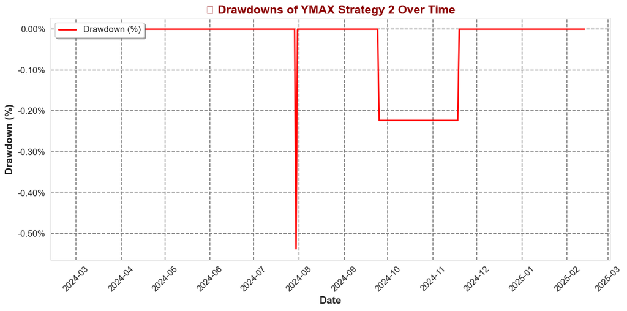

```python
# ---------------------------------------------
# STEP 2: Plot Drawdown Over Time
# ---------------------------------------------
sns.set_style("whitegrid")
plt.figure(figsize=(12, 6))

ax = sns.lineplot(
    x=ymax_df["Date"],
    y=drawdown_percentage,
    color="red",
    linewidth=2,
    label="Drawdown (%)"
)

# Format X-axis to display months
ax.xaxis.set_major_locator(mdates.MonthLocator())
ax.xaxis.set_major_formatter(mdates.DateFormatter("%Y-%m"))
plt.xticks(rotation=45, fontsize=12)
plt.yticks(fontsize=12)

# Format Y-axis labels as percentages (e.g., -1.00%, -2.00%)
ax.yaxis.set_major_formatter(mticker.FuncFormatter(lambda y, pos: f"{y:.2f}%"))

plt.xlabel("Date", fontsize=14, fontweight="bold")
plt.ylabel("Drawdown (%)", fontsize=14, fontweight="bold")
plt.title("📉 Drawdowns of YMAX Strategy 2 Over Time", fontsize=16, fontweight="bold", color="darkred")

# Add thick, colored grid lines
plt.grid(True, linestyle="--", linewidth=1.2, color="gray")

plt.legend(fontsize=12, loc="upper left", frameon=True, shadow=True)
plt.tight_layout()
plt.show()
```

```python
# Display the performance metrics for YMAX
performance_df_ymax = performance_df
performance_df_ymax = performance_df_ymax.round(2)
performance_df_ymax
```

|  | Total Return (%) | CAGR (%) | Annualized Volatility (%) | Sharpe Ratio | Max Drawdown (%) | Calmar Ratio |
| --- | --- | --- | --- | --- | --- | --- |
| YMAX Strategy 2 | 7.09 | 7.43 | 3.26 | 1.67 | -0.54 | 13.83 |

## YMAG BACKTEST

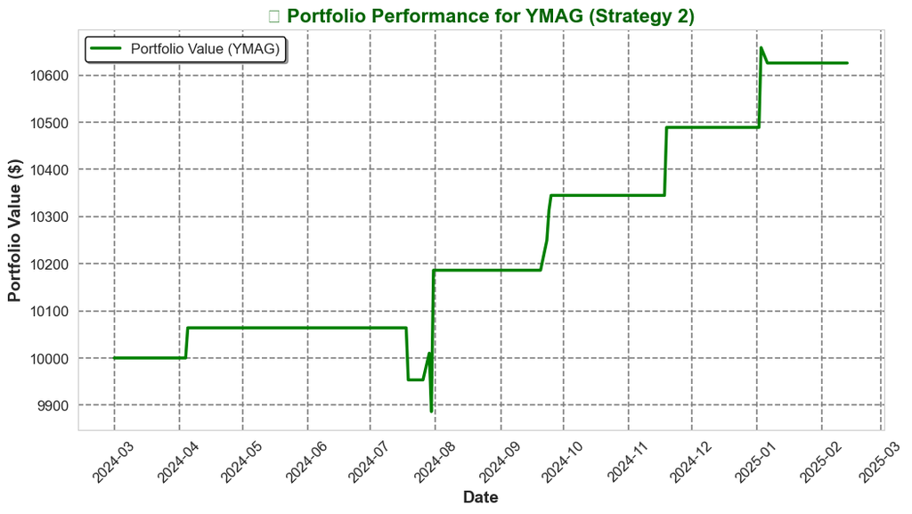

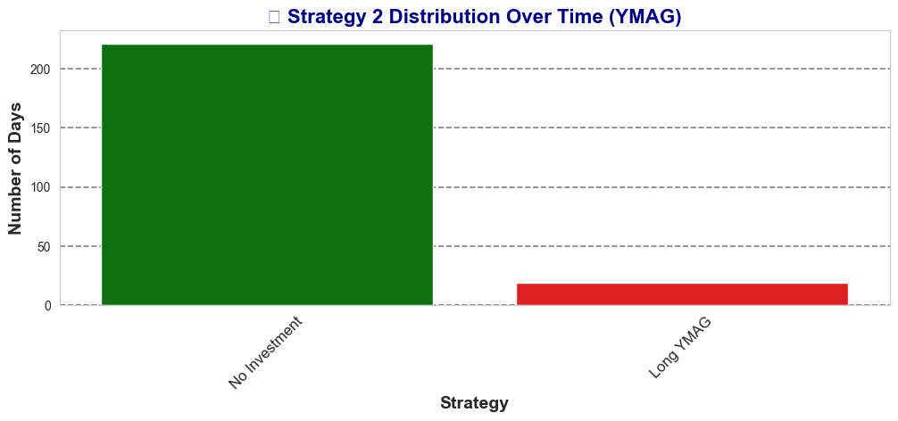

```python
# ------------------------------------------------------------
# 1) PREPARE THE DATA
# ------------------------------------------------------------
# Copy the cleaned DataFrame for YMAG backtesting.
ymag_df = Prices_and_stats_df.copy()

# Define initial portfolio value
initial_investment = 10000.0  # $10,000 starting capital

# Sort by date to ensure chronological order
ymag_df.sort_values("Date", inplace=True)
ymag_df.reset_index(drop=True, inplace=True)

# ------------------------------------------------------------
# 2) DEFINE HELPER FUNCTIONS FOR CONDITIONS
# ------------------------------------------------------------
def in_market_condition(vix, vvix):
    """
    Condition for staying in the market once we're already invested:
    15 <= VIX <= 20, and 90 <= VVIX < 100.
    """
    return (15 <= vix <= 20) and (90 <= vvix < 100)

def reentry_condition(vix, vvix):
    """
    Stricter condition for re-entering the market after an exit:
    15 <= VIX <= 20, and 90 <= VVIX <= 95.
    """
    return (15 <= vix <= 20) and (90 <= vvix <= 95)

def exit_condition(vix, vvix):
    """
    Exit the market if VIX < 15 or VIX > 20, or if VVIX < 90 or VVIX >= 100.
    """
    return (vix < 15) or (vix > 20) or (vvix < 90) or (vvix >= 100)

# ------------------------------------------------------------
# 3) SET UP BACKTEST COLUMNS AND INITIAL VALUES
# ------------------------------------------------------------
ymag_df["Portfolio_Value"] = np.nan
ymag_df.loc[0, "Portfolio_Value"] = initial_investment

# Boolean: are we currently invested?
ymag_df["In_Market"] = False
ymag_df.loc[0, "In_Market"] = False

# Track how many shares of YMAG we hold
ymag_df["Shares_Held"] = 0.0
ymag_df.loc[0, "Shares_Held"] = 0.0

# Strategy label for each day
ymag_df["Strategy"] = "No Investment"

# ------------------------------------------------------------
# 4) BACKTEST LOOP
# ------------------------------------------------------------
for i in range(1, len(ymag_df)):
    # Carry forward previous day's portfolio value, in_market status, and shares
    ymag_df.loc[i, "Portfolio_Value"] = ymag_df.loc[i-1, "Portfolio_Value"]
    ymag_df.loc[i, "In_Market"] = ymag_df.loc[i-1, "In_Market"]
    ymag_df.loc[i, "Shares_Held"] = ymag_df.loc[i-1, "Shares_Held"]

    # Current day data
    vix_today = ymag_df.loc[i, "VIX"]
    vvix_today = ymag_df.loc[i, "VVIX"]
    ymag_price_today = ymag_df.loc[i, "YMAG"]
    ymag_div_today = ymag_df.loc[i, "YMAG Dividends"]

    # Check if we are currently in the market
    currently_in_market = ymag_df.loc[i-1, "In_Market"]

    if currently_in_market:
        # If in the market, check if exit condition is met
        if exit_condition(vix_today, vvix_today):
            # EXIT: close position -> set shares to 0, mark as not in market
            ymag_df.loc[i, "In_Market"] = False
            ymag_df.loc[i, "Shares_Held"] = 0.0
            ymag_df.loc[i, "Strategy"] = "No Investment"
            # Portfolio value is carried forward (no update)
        else:
            # REMAIN IN MARKET: update portfolio value based on today's YMAG price and dividend
            shares_held = ymag_df.loc[i, "Shares_Held"]
            new_portfolio_value = shares_held * (ymag_price_today + ymag_div_today)
            ymag_df.loc[i, "Portfolio_Value"] = new_portfolio_value
            ymag_df.loc[i, "Strategy"] = "Long YMAG"
    else:
        # If not in the market, check re-entry condition
        if reentry_condition(vix_today, vvix_today):
            # ENTER: invest all available cash
            cash_available = ymag_df.loc[i, "Portfolio_Value"]
            if ymag_price_today > 0:
                shares_bought = cash_available / ymag_price_today
                ymag_df.loc[i, "Shares_Held"] = shares_bought
                ymag_df.loc[i, "In_Market"] = True
                ymag_df.loc[i, "Strategy"] = "Long YMAG"
                # Update portfolio value immediately with today's price and dividend
                new_portfolio_value = shares_bought * (ymag_price_today + ymag_div_today)
                ymag_df.loc[i, "Portfolio_Value"] = new_portfolio_value
            else:
                ymag_df.loc[i, "Strategy"] = "No Investment"
        else:
            # Otherwise, remain out of the market
            ymag_df.loc[i, "Strategy"] = "No Investment"

# ------------------------------------------------------------
# 5) COMPUTE DAILY RETURNS
# ------------------------------------------------------------
ymag_df["Portfolio_Return"] = ymag_df["Portfolio_Value"].pct_change()

# ------------------------------------------------------------
# 6) VISUALIZE RESULTS
# ------------------------------------------------------------
sns.set_style("whitegrid")

# (A) Portfolio Performance Plot for YMAG
plt.figure(figsize=(12, 6))
ax = sns.lineplot(
    x=ymag_df["Date"],
    y=ymag_df["Portfolio_Value"],
    color="green",
    linewidth=2.5,
    label="Portfolio Value (YMAG)"
)
ax.xaxis.set_major_locator(mdates.MonthLocator())
ax.xaxis.set_major_formatter(mdates.DateFormatter("%Y-%m"))
plt.xlabel("Date", fontsize=14, fontweight="bold")
plt.ylabel("Portfolio Value ($)", fontsize=14, fontweight="bold")
plt.title("📈 Portfolio Performance for YMAG (Strategy 2)", fontsize=16, fontweight="bold", color="darkgreen")
plt.xticks(rotation=45, fontsize=12)
plt.yticks(fontsize=12)
plt.grid(True, linestyle="--", linewidth=1.2, color="gray")
plt.legend(fontsize=12, loc="upper left", frameon=True, shadow=True, edgecolor="black")
plt.show()

# (B) Strategy Usage Over Time for YMAG
plt.figure(figsize=(12, 4))
ax = sns.barplot(
    x=ymag_df["Strategy"].value_counts().index,
    y=ymag_df["Strategy"].value_counts().values,
    palette=["green", "red", "blue"]
)
plt.xlabel("Strategy", fontsize=14, fontweight="bold")
plt.ylabel("Number of Days", fontsize=14, fontweight="bold")
plt.title("📊 Strategy 2 Distribution Over Time (YMAG)", fontsize=16, fontweight="bold", color="navy")
plt.xticks(rotation=45, fontsize=12)
plt.grid(axis="y", linestyle="--", linewidth=1.2, color="gray")
plt.show()
```

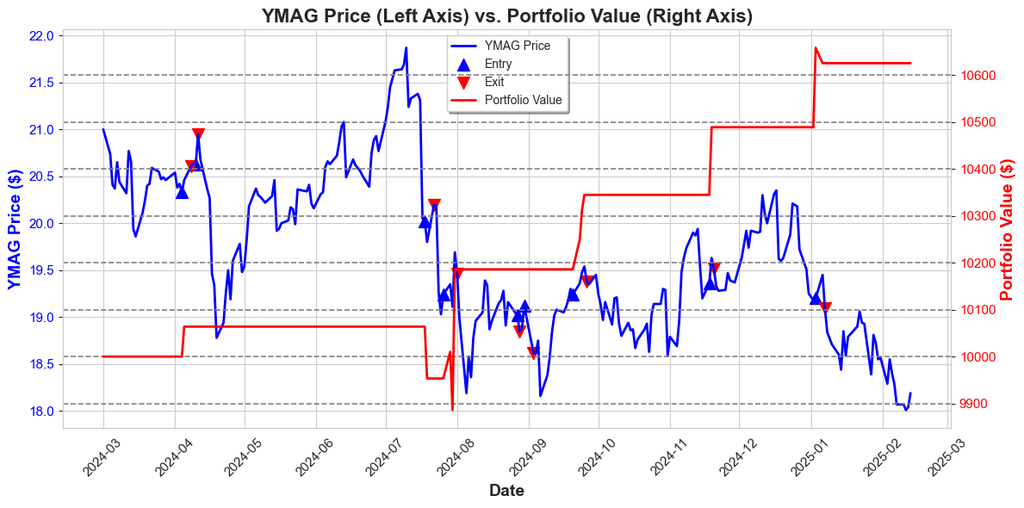

```python
# ---------------------------------------------
# STEP A: Identify Entry and Exit Days for YMAG
# ---------------------------------------------
# Entry Day = Yesterday was out of market, today is in market
ymag_df["Entry"] = (ymag_df["In_Market"].shift(1) == False) & (ymag_df["In_Market"] == True)

# Exit Day = Yesterday was in market, today is out of market
ymag_df["Exit"] = (ymag_df["In_Market"].shift(1) == True) & (ymag_df["In_Market"] == False)

# ---------------------------------------------
# STEP B: Prepare Data for Plotting
# ---------------------------------------------
entry_days = ymag_df[ymag_df["Entry"] == True]
exit_days  = ymag_df[ymag_df["Exit"] == True]

# Sort data by date (just to be safe)
ymag_df.sort_values("Date", inplace=True)
ymag_df.reset_index(drop=True, inplace=True)

# ---------------------------------------------
# STEP C: Create the Dual-Axis Plot for YMAG
# ---------------------------------------------
sns.set_style("whitegrid")
fig, ax1 = plt.subplots(figsize=(12, 6))

# LEFT Y-AXIS: Plot YMAG Price
ax1.set_xlabel("Date", fontsize=14, fontweight="bold")
ax1.set_ylabel("YMAG Price ($)", fontsize=14, fontweight="bold", color="blue")

# Plot YMAG Price line
line1, = ax1.plot(
    ymag_df["Date"],
    ymag_df["YMAG"],
    color="blue",
    linewidth=2,
    label="YMAG Price"
)

# Add entry (^) and exit (v) markers on YMAG Price
ax1.scatter(
    entry_days["Date"],
    entry_days["YMAG"],
    marker="^",
    color="blue",
    s=100,
    label="Entry"
)
ax1.scatter(
    exit_days["Date"],
    exit_days["YMAG"],
    marker="v",
    color="red",
    s=100,
    label="Exit"
)

# Make the left y-axis text blue for clarity
ax1.tick_params(axis='y', labelcolor="blue")

# Format the date axis on x-axis
ax1.xaxis.set_major_locator(mdates.MonthLocator())
ax1.xaxis.set_major_formatter(mdates.DateFormatter("%Y-%m"))
plt.xticks(rotation=45, fontsize=11)
plt.yticks(fontsize=11)

# ---------------------------------------------
# RIGHT Y-AXIS: Plot Portfolio Value
# ---------------------------------------------
ax2 = ax1.twinx()  # share the same x-axis
ax2.set_ylabel("Portfolio Value ($)", fontsize=14, fontweight="bold", color="red")

line2, = ax2.plot(
    ymag_df["Date"],
    ymag_df["Portfolio_Value"],
    color="red",
    linewidth=2,
    label="Portfolio Value"
)
ax2.tick_params(axis='y', labelcolor="red")
plt.yticks(fontsize=11)

# ---------------------------------------------
# STEP D: Enhance the Plot
# ---------------------------------------------
plt.title("YMAG Price (Left Axis) vs. Portfolio Value (Right Axis)", fontsize=16, fontweight="bold")
plt.grid(True, linestyle="--", linewidth=1.2, color="gray")

# Combine legends from both axes
lines_1, labels_1 = ax1.get_legend_handles_labels()
lines_2, labels_2 = ax2.get_legend_handles_labels()
ax1.legend(lines_1 + lines_2, labels_1 + labels_2, loc="upper center", frameon=True, shadow=True)

plt.tight_layout()
plt.show()
```

```python
# ---------------------------------------------
# STEP A: Identify Entry and Exit Days for YMAG
# ---------------------------------------------
ymag_df["Entry"] = (ymag_df["In_Market"].shift(1) == False) & (ymag_df["In_Market"] == True)
ymag_df["Exit"]  = (ymag_df["In_Market"].shift(1) == True) & (ymag_df["In_Market"] == False)

# ---------------------------------------------
# STEP B: Prepare Data for Plotting
# ---------------------------------------------
entry_days = ymag_df[ymag_df["Entry"] == True]
exit_days  = ymag_df[ymag_df["Exit"] == True]

# Sort data by date (just to be safe)
ymag_df.sort_values("Date", inplace=True)
ymag_df.reset_index(drop=True, inplace=True)

# ---------------------------------------------
# STEP C: Create the Plotly Figure for YMAG
# ---------------------------------------------
fig = go.Figure()

# 1) YMAG Price (Left Axis)
fig.add_trace(
    go.Scatter(
        x=ymag_df["Date"],
        y=ymag_df["YMAG"],
        mode="lines",
        line=dict(color="blue", width=2),
        name="YMAG Price",
        yaxis="y1"
    )
)

# 2) Entry Markers (triangle-up)
fig.add_trace(
    go.Scatter(
        x=entry_days["Date"],
        y=entry_days["YMAG"],
        mode="markers",
        marker=dict(symbol="triangle-up", color="blue", size=12),
        name="Entry",
        yaxis="y1"
    )
)

# 3) Exit Markers (triangle-down)
fig.add_trace(
    go.Scatter(
        x=exit_days["Date"],
        y=exit_days["YMAG"],
        mode="markers",
        marker=dict(symbol="triangle-down", color="red", size=12),
        name="Exit",
        yaxis="y1"
    )
)

# 4) Portfolio Value (Right Axis)
fig.add_trace(
    go.Scatter(
        x=ymag_df["Date"],
        y=ymag_df["Portfolio_Value"],
        mode="lines",
        line=dict(color="red", width=2),
        name="Portfolio Value",
        yaxis="y2"
    )
)

# ---------------------------------------------
# STEP D: Configure Layout for Dual Axis and Legend Position
# ---------------------------------------------
fig.update_layout(
    title="YMAG Price (Left Axis) vs. Portfolio Value (Right Axis) - Interactive Plotly",
    xaxis=dict(
        title="Date",
        type="date",
        tickformat="%Y-%m",
        tickangle=45
    ),
    yaxis=dict(
        title="YMAG Price ($)",
        side="left",
        showgrid=False,
        color="blue"
    ),
    yaxis2=dict(
        title="Portfolio Value ($)",
        side="right",
        overlaying="y",
        position=1.0,
        showgrid=True,
        gridwidth=1,
        gridcolor="lightgray",
        color="red"
    ),
    legend=dict(
        x=0.5,
        y=1.0,
        xanchor='center',
        yanchor='top',
        bgcolor="rgba(255,255,255,0.7)",
        bordercolor="black",
        borderwidth=1
    ),
    hovermode="x unified"
)

# ---------------------------------------------
# STEP E: Show Interactive Figure
# ---------------------------------------------
fig.show()
```

##### PERFORMANCE METRICS FOR YMAG

```python
# ------------------------------------------------------------
# 1) COMPUTE PERFORMANCE METRICS FOR YMAG
# ------------------------------------------------------------

# Compute daily returns from portfolio value for YMAG
ymag_df["Portfolio_Return"] = ymag_df["Portfolio_Value"].pct_change()

performance_metrics_ymag = {}

# Total Return (%) for YMAG
performance_metrics_ymag["Total Return (%)"] = (ymag_df["Portfolio_Value"].iloc[-1] / ymag_df["Portfolio_Value"].iloc[0] - 1) * 100

# CAGR (Compounded Annual Growth Rate) for YMAG
num_days = (ymag_df["Date"].iloc[-1] - ymag_df["Date"].iloc[0]).days
years = num_days / 365
performance_metrics_ymag["CAGR (%)"] = ((ymag_df["Portfolio_Value"].iloc[-1] / ymag_df["Portfolio_Value"].iloc[0]) ** (1 / years) - 1) * 100

# Annualized Volatility (%) for YMAG
performance_metrics_ymag["Annualized Volatility (%)"] = ymag_df["Portfolio_Return"].std() * np.sqrt(252) * 100

# Sharpe Ratio for YMAG (assuming risk-free rate = 2%)
risk_free_rate = 0.02
sharpe_ratio_ymag = (performance_metrics_ymag["CAGR (%)"] / 100 - risk_free_rate) / (performance_metrics_ymag["Annualized Volatility (%)"] / 100)
performance_metrics_ymag["Sharpe Ratio"] = sharpe_ratio_ymag

# Max Drawdown (%) Calculation for YMAG
rolling_max_ymag = ymag_df["Portfolio_Value"].cummax()
drawdown_ymag = (ymag_df["Portfolio_Value"] / rolling_max_ymag) - 1  # Decimal values
drawdown_percentage_ymag = drawdown_ymag * 100  # Convert to percentage
performance_metrics_ymag["Max Drawdown (%)"] = drawdown_percentage_ymag.min()  # Most negative value

# Calmar Ratio for YMAG (CAGR divided by absolute Max Drawdown)
max_drawdown_abs_ymag = abs(performance_metrics_ymag["Max Drawdown (%)"])
performance_metrics_ymag["Calmar Ratio"] = performance_metrics_ymag["CAGR (%)"] / max_drawdown_abs_ymag if max_drawdown_abs_ymag != 0 else np.nan

# Convert performance metrics to a DataFrame for display
performance_df_ymag = pd.DataFrame(performance_metrics_ymag, index=["YMAG Strategy 2"])
```

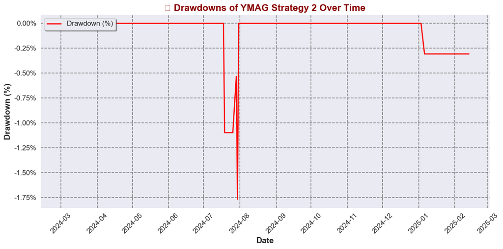

```python
# ------------------------------------------------------------
# 2) PLOT DRAWDOWNS OVER TIME FOR YMAG
# ------------------------------------------------------------
sns.set_style("darkgrid")
plt.figure(figsize=(12, 6))

ax = sns.lineplot(
    x=ymag_df["Date"],
    y=drawdown_percentage_ymag,
    color="red",
    linewidth=2,
    label="Drawdown (%)"
)

# Format X-axis to display one tick per month
ax.xaxis.set_major_locator(mdates.MonthLocator())
ax.xaxis.set_major_formatter(mdates.DateFormatter("%Y-%m"))
plt.xticks(rotation=45, fontsize=12)
plt.yticks(fontsize=12)

# Format Y-axis labels to show percentages with two decimal places
ax.yaxis.set_major_formatter(mticker.FuncFormatter(lambda y, pos: f"{y:.2f}%"))

plt.xlabel("Date", fontsize=14, fontweight="bold")
plt.ylabel("Drawdown (%)", fontsize=14, fontweight="bold")
plt.title("📉 Drawdowns of YMAG Strategy 2 Over Time", fontsize=16, fontweight="bold", color="darkred")

# Add thicker, colored grid lines for better visibility
plt.grid(True, linestyle="--", linewidth=1.2, color="gray")
plt.legend(fontsize=12, loc="upper left", frameon=True, shadow=True)
plt.tight_layout()
plt.show()
```

```python
# Display the performance metrics for YMAX
performance_df_ymag = performance_df_ymag.round(2)
performance_df_ymag
```

|  | Total Return (%) | CAGR (%) | Annualized Volatility (%) | Sharpe Ratio | Max Drawdown (%) | Calmar Ratio |
| --- | --- | --- | --- | --- | --- | --- |
| YMAG Strategy 2 | 6.26 | 6.55 | 4.37 | 1.04 | -1.77 | 3.71 |

```python
# 1️⃣ Convert portfolio returns to 2-decimal percentage
ymax_df["Portfolio_Return"] = (ymax_df["Portfolio_Return"] * 100).round(2)
ymag_df["Portfolio_Return"] = (ymag_df["Portfolio_Return"] * 100).round(2)

# 2️⃣ Rename the 'Portfolio_Return' column to 'Portfolio_Return (%)'
ymax_df.rename(columns={"Portfolio_Return": "Portfolio_Return (%)"}, inplace=True)
ymag_df.rename(columns={"Portfolio_Return": "Portfolio_Return (%)"}, inplace=True)

# 3️⃣ Export the data to Excel
output_filename = "Strategy 2 Performance.xlsx"

with pd.ExcelWriter(output_filename, engine="xlsxwriter") as writer:
    # Sheet 1: Raw data (Prices_and_stats_df)
    Prices_and_stats_df.to_excel(writer, sheet_name="Sheet1", index=False)

    # Sheet 2: YMAX trading results
    ymax_df.to_excel(writer, sheet_name="Ymax Trading Results", index=False)

    # Sheet 3: YMAG trading results
    ymag_df.to_excel(writer, sheet_name="YMAG Trading Results", index=False)

    # Sheet 4: YMAX Performance Metrics
    performance_df_ymax.to_excel(writer, sheet_name="YMAX Performance", index=True)

    # Sheet 5: YMAG Performance Metrics
    performance_df_ymag.to_excel(writer, sheet_name="YMAG Performance", index=True)

print(f"✅ All DataFrames successfully saved to '{output_filename}'")
```

```
✅ All DataFrames successfully saved to 'Strategy 2 Performance.xlsx'
```

### **📌 Investment Rules for Strategy 3:**

1. **Rule 2**: If **VIX is above 20**, **Long YMAX/YMAG (no hedge)** and remain fully invested.
2. **Rule 4**: If **VVIX goes above 100**, **exit the market** (close all positions).
3. **Rule 5**: Re-enter the market when **VVIX drops back below 95 or 90** (to avoid losses and whipsaws).

##### **📌 Summary**

- **Exit conditions** are based on **VVIX spikes above 100**.
- **Re-entry conditions** trigger only when **VVIX stabilizes under 95-90**.

### **📌 Investment Rules for Strategy 4:**

1. **Rule 1**: If **VIX is under 15**, **Long YMAX/YMAG (no hedge)** and backtest separately to analyze performance.
2. **Rule 2**: If **VVIX goes above 100**, **exit the market** (close all positions).
3. **Rule 3**: Re-enter the market when **VVIX drops back below 95 or 90** (to avoid losses and whipsaws).

##### **📌 Summary**

- **Exit conditions** are based on **VVIX spikes above 100**.
- **Re-entry conditions** trigger only when **VVIX stabilizes under 95-90**.